# Cluster Assignment and Stratified Covariate Constrained Randomization for Spatially-Correlated Data: Euclidean Distances

Patrick Iben

July 19, 2020

In malaria research, interventions are often applied to communities, not individuals, such as spraying of insecticides, distribution of medications to health centers, or bed net campaigns. CCR is a potentially beneficial method for assigning treatments to communities. However, spatial heterogeneity needs to be considered, as mosquitoes and people move frequently, and the potential for treatment contamination is high. Thus, it is desirable to optimize community assignment to clusters that are contiguous, yet still achieve random assignment of clusters to intervention arms. This document provides a method on selecting clusters and treatment assignments for stratified cluster randomized trials, via covariate-constrained randomization and from spatially-correlated data. Three clustering techniques are used: K-Means; Clustering Large Applications (CLARA); Ward Hierarchical Clustering. The distance metric is Euclidean distance. Optimal treatment assignments are determined by: balance on strata, evidence of spatial heterogeneity of treatment assignments, and randomly-selected CCR score. Optimal design selection is based on which of the three selected CCR schemes is the lowest, while also being balanced on the strata and exhibiting spatial heterogeneity, thus helping minimize spatial contamination. All clustering and CCR algorithms for each of the three methods are placed in while loops, with seeds starting at 1. If a selected randomization scheme for a given method is not balanced on strata and exhibiting spatial heterogeneity of treatment arms, the loop starts over with 1 added to the seed and repeat until such a scheme was chosen.

For this data scenario, the three covariates on which we are constraining CRT design are cluster-level: baseline malaria prevalence (via microscopy), household density, and proportion bordering a still body of water.

After loading necessary packages and setting the directory, spatial feature and geo-location data are read in and cleaned, to merge into spatial polygons data frame. After the study data has been merged with the geo-location data, subsets are made of each sub-county(stratum). This will allow us to maintain the separation of sub-counties during cluster optimization.

As CRTs tend to have only two treatment arms for which to randomize clusters (treatment and control), only even number of clusters can be considered to evenly assign units. For this example, the one stratification variable - subcounty - has two levels. Thus, to best assure even allocation of the two trial arms into the two strata levels (though not a guarantee), only cluster sizes divisible by four should be considered. If only four clusters are created, then there are a total of six (4 choose 2) configurations to select randomly from for CCR.

If the default cutoff for cvrall() of 10% is used, then this leaves only one treatment allocation scheme to select from, thus creating a deterministic selection for cluster assignment - and no longer qualifies as a randomized control trial. To remove this possibility, only multiples of four, that are greater than or equal to eight, are considered.

```r
#Setting minimum K for cluster size -
minclust <- 8
#Setting maximum K for cluster size to ensure at least 3 units per cluster for buffer
n_3 <- round((nrow(study_data_wide))/3)
n_3_even <- ifelse(n_3 %% 2 != 0, n_3-1, n_3)#If odd, subtract 1
n_3_divby4 <- ifelse(n_3_even %% 4 != 0, n_3_even-2, n_3_even)#If not divisible by 4, subtract 2

#If ((closest even number under number of units divided by 3) *3)) is greater than number of units, then subtract 4 from previous line for the maximum cluster size
maxclust <- ifelse((n_3_divby4*3) > nrow(study_data_wide), n_3_divby4-4, n_3_divby4)

paste("For this example, a maximum of ", maxclust, " clusters will be tested", sep="")
```

```
## [1] "For this example, a maximum of 16 clusters will be tested"
```

“cvcrand” allows for custom weighting of covariate importance while performing CCR. For this example, we use standardized regression coefficients from a Poisson cell-means model with an offset via the glm() function. The outcome of interest is the count of positive malaria tests from the most survey data. We are using standardized village-level data (due to the sparsity of cluster-level data); to standardize the data, the scale() function is used. The regression coefficients are standardized such that their absolute values sum to 1 - the relative weight of a given covariate is defined as the absolute value of its model coefficient divided by the sum of the absolute values of all model coefficients. To keep consistent with package author guidelines of weights greater than 1, each weight is then multiplied by 100.

```r
#Scaling covariates (not outcome or offset)
study_data_wide$scaled_microPos_1 <- scale(study_data_wide$microPos_1)
study_data_wide$scaled_BordersWater <- scale(study_data_wide$BordersWater)
study_data_wide$scaled_hhDensity <- scale(study_data_wide$hhDensity)

#Creating Poisson model with offset
weight_model <- glm(microPos_5 ~ scaled_microPos_1 + scaled_BordersWater + scaled_hhDensity+ offset(log(microTests_5)) -1,
                 data=study_data_wide, family = poisson)
summary(weight_model)
```

```
##
## Call:
## glm(formula = microPos_5 ~ scaled_microPos_1 + scaled_BordersWater +
##     scaled_hhDensity + offset(log(microTests_5)) - 1, family = poisson,
##     data = study_data_wide)
##
## Deviance Residuals:
##     Min       1Q   Median       3Q      Max
## -11.423   -8.787   -7.753   -6.016   -3.556
##
## Coefficients:
##                     Estimate Std. Error z value Pr(>|z|)
## scaled_microPos_1   -0.22025    0.02326  -9.468  < 2e-16 ***
## scaled_BordersWater -0.09691    0.02287  -4.238 2.26e-05 ***
## scaled_hhDensity     0.11830    0.02147   5.510 3.59e-08 ***
## ---
## Signif. codes:  0 '***' 0.001 '**' 0.01 '*' 0.05 '.' 0.1 ' ' 1
##
## (Dispersion parameter for poisson family taken to be 1)
##
##     Null deviance: 3557.4  on 55  degrees of freedom
## Residual deviance: 3321.9  on 52  degrees of freedom
## AIC: 3487
##
## Number of Fisher Scoring iterations: 7
```

```r
#Scaling and saving model coefficients for CCR weights
weights_raw <- c(abs(weight_model$coefficients[1][[1]])/sum(abs(weight_model$coefficients)), abs(weight_model$coefficients[2][[1]])/sum(abs(weight_model$coefficients)), abs(weight_model$coefficients[3][[1]])/sum(abs(weight_model$coefficients)))

#Saving scaled weights
weights <- weights_raw * 100

#Subsetting variables of interest for cluster-level summary stats
CCR_covariates <- study_data_wide[,c("microPos_1", "microTests_1", "BordersWater", "hh", "areakm2", "county")]

#Naming cluster summary statistics for CCR
#For this data scenario, the overall cluster-level summary statistics are: baseline microscopy rate, household density, and proportion of cluster bordering water.
Cluster_SumStats <- c("Cluster_mRate_1", "Cluster_hhDensity", "Cluster_prop_BordersWater")
#Naming strata
Strata <- "county"
#Merging names
CCR_SumStats_Strata <- c(Cluster_SumStats, Strata)
```

CCR Optimization

Below, all three cluster optimization methods are optimized for stratified, weighted CCR.

K-Means:

```r
kmeans_best_ccr<-NA
seed <- 1
while (is.na(kmeans_best_ccr)){

#Initializing listing of cluster assignments for each value of K
clustering_list <- list()

#Collecting cluster quality statistics across range of cluster sizes
for(i in seq(minclust,maxclust, by = 4)){
  set.seed(seed)
  clustering_list[[i-(minclust-1)]] <- rbind(c(kmeans(geo_data_subcounty_1, i/2)$cluster,kmeans(geo_data_subcounty_3, i/2)$cluster),geo_data_subcountyname$subcounty)
  clustering_list[[i-(minclust-1)]][1,] <- ifelse(clustering_list[[i-(minclust-1)]][2,]=="1", clustering_list[[i-(minclust-1)]][1,] + (i/2), clustering_list[[i-(minclust-1)]][1,])
}

#Stripping null list elements
clustering_list[sapply(clustering_list, is.null)] <- NULL

#Adding labels
names(clustering_list) <- seq(minclust,maxclust, by= 4)

#Converting from list to matrix
#Initializing
kmeans_cluster_assignments <- matrix(data = NA, nrow = nrow(geo_data), ncol = length(clustering_list), byrow = FALSE,dimnames = NULL)

for(i in 1:length(clustering_list)){
  kmeans_cluster_assignments[,i] <- clustering_list[[i]][1,]
  colnames(kmeans_cluster_assignments) <- cat("kmeans_",max(kmeans_cluster_assignments[,i]), sep = "")
}

colnames(kmeans_cluster_assignments) <- paste("kmeans_", seq(minclust,maxclust, by= 4), sep = "")
rownames(kmeans_cluster_assignments) <- names(clustering_list[[1]][1,])

#Merging into main dataframe
study_data_wide <- merge(kmeans_cluster_assignments, study_data_wide,by = "row.names")

study_data_wide$Row.names <- NULL

#K-Means CCR

#Adding in village code to merge with lat/long. (for spatial clustering test)
village_code <- rownames(kmeans_cluster_assignments)
kmeans_cluster_assignments_df <- data.frame(cbind(kmeans_cluster_assignments, village_code))

#Saving spatial location as df for merging
geo_data_df <- data.frame(geo_data)
colnames(geo_data_df) <- c("village_long", "village_lat")
geo_data_df$village_code <- rownames(geo_data_df)

#Initializing listing of cluster assignments for each value of K
kmeans_sumstats <- list()
kmeans_ccr <-list()
kmeans_spat_clust <- list()
trt_loc <- list()
split_trt_loc <- list()
spat_clust <- matrix(data = NA, nrow = ncol(kmeans_cluster_assignments), ncol = 1, byrow = FALSE,dimnames = NULL)
ccr_selected <- matrix(data = NA, nrow = ncol(kmeans_cluster_assignments), ncol = 1, byrow = FALSE,dimnames = NULL)
balanced_strata <- matrix(data = NA, nrow = ncol(kmeans_cluster_assignments), ncol = 1, byrow = FALSE,dimnames = NULL)

#Saving cluster summary statistics for balancing
for(i in 1:ncol(kmeans_cluster_assignments)){
kmeans_sumstats[[i]] <- data.frame(cbind(kmeans_cluster_assignments[,i],CCR_covariates))

kmeans_sumstats[[i]][,"Cluster_mRate_1"] <- with(kmeans_sumstats[[i]], ave(microPos_1, kmeans_sumstats[[i]][,1], FUN=sum)) / with(kmeans_sumstats[[i]], ave(microTests_1, kmeans_sumstats[[i]][,1], FUN=sum))

kmeans_sumstats[[i]][,"Cluster_hhDensity"] <- with(kmeans_sumstats[[i]], ave(hh, kmeans_sumstats[[i]][,1], FUN=sum)) / with(kmeans_sumstats[[i]], ave(areakm2, kmeans_sumstats[[i]][,1], FUN=sum))

kmeans_sumstats[[i]][,"Cluster_prop_BordersWater"] <- with(kmeans_sumstats[[i]], ave(as.numeric(BordersWater), kmeans_sumstats[[i]][,1], FUN=sum)) / with(kmeans_sumstats[[i]], ave(as.numeric(BordersWater), kmeans_sumstats[[i]][,1], FUN=length))

#Ensuring sorted by clustering
kmeans_sumstats[[i]] <- kmeans_sumstats[[i]][order(kmeans_sumstats[[i]][,1]),]

#Outputting one row per subgroup summary stats
kmeans_sumstats[[i]] <- kmeans_sumstats[[i]][!duplicated(kmeans_sumstats[[i]][,1]),]

#CCR
kmeans_ccr[[i]] <- cvrall(clustername = kmeans_sumstats[[i]][,1],
                  balancemetric = "l2",
                  x = data.frame(kmeans_sumstats[[i]][ ,CCR_SumStats_Strata]),
                  ntotal_cluster = length(kmeans_sumstats[[i]][,1]),
                  ntrt_cluster = length(kmeans_sumstats[[i]][,1])/2,
                  weights = c(weights, 1000),
                  categorical = Strata,
                  cutoff = 0.1,
                  size = 25000000,
                  bhist = F,
                  seed = seed)

#Labeling treatment assignments
names(kmeans_ccr[[i]]$allocation) <- c(paste("kmeans_", length(kmeans_sumstats[[i]][,1]), sep = ""), paste("kmeans_", length(kmeans_sumstats[[i]][,1]), "_trt", sep = ""))

kmeans_cluster_assignments_df <- merge(kmeans_cluster_assignments_df, kmeans_ccr[[i]]$allocation)
kmeans_cluster_assignments_df$village_code <- as.character(kmeans_cluster_assignments_df$village_code)

#Merging with left_join() to keep row order
kmeans_cluster_assignments_df <- left_join(geo_data_df, kmeans_cluster_assignments_df)

#Saving separate dataframes of treatment assignments with their spatial location data (coordinates)
trt_loc[[i]] <- data.frame(cbind(select(kmeans_cluster_assignments_df, ends_with("_trt"))[i]), geo_data_df)

#Split by treatment group
split_trt_loc[[i]] <- split(trt_loc[[i]], trt_loc[[i]][1])

#Testing for significant differences in mean nn-dist with Welch Two Sample t-test
spat_clust[i,] <- ifelse(t.test(nndist(split_trt_loc[[i]]$`0`$village_lat, split_trt_loc[[i]]$`0`$village_long), nndist(split_trt_loc[[i]]$`1`$village_lat, split_trt_loc[[i]]$`1`$village_long))$p.value < 0.05, 1, 0)

#Testing for balance on strata
balanced_strata[i,] <- ifelse(regmatches(kmeans_ccr[[i]]$baseline_table$`arm = 0`[5], gregexpr("(?<=\\().*?(?=\\))", kmeans_ccr[[i]]$baseline_table$`arm = 0`[5], perl=T))[[1]] == "50.0" && regmatches(kmeans_ccr[[i]]$baseline_table$`arm = 1`[5], gregexpr("(?<=\\().*?(?=\\))", kmeans_ccr[[i]]$baseline_table$`arm = 1`[5], perl=T))[[1]] == "50.0"
,1,0)

#Saving selected ccr scores
ccr_selected[i,] <- as.numeric(kmeans_ccr[[i]]$bscores[1,2])
}

#Combining selected scores, whether or not there is evidence of spatial
#heterogeneity, and whether or not strata are balanced
ccr_all <- data.frame(ccr_selected,spat_clust,balanced_strata)

#Selecting schemes that are balanced on strata and exhibit spatial heterogeneity
ccr_bal_clust <- ccr_all[which(ccr_all$spat_clust == 1 & ccr_all$balanced_strata == 1),]

#IDing lowest selected score
lowest_index <- as.numeric(rownames(ccr_bal_clust[which.min(ccr_bal_clust[,1]),]))
kmeans_best_ccr <- ifelse(length(lowest_index) == 0, NA, kmeans_ccr[lowest_index])
seed <- seed + 1
}
```

```
## kmeans_8kmeans_12kmeans_16kmeans_8kmeans_12kmeans_16kmeans_8kmeans_12kmeans_16
```

```r
paste("Seed: ",seed,sep = "")
```

```
## [1] "Seed: 4"
```

```r
seed_kmeans <- seed
seed_mat <- data.matrix(seed_kmeans)
colnames(seed_mat) <- "Seed"

#Isolating clustername and treatment arm
kmeans_ccr_mat <- cbind(kmeans_best_ccr[[1]]$allocation[1], kmeans_best_ccr[[1]]$allocation[2])
colnames(kmeans_ccr_mat) <- c("kmeans_cluster", "kmeans_treatment_arm")

#Saving best configuration
kmeans_optimized_treatments <- as.matrix(kmeans_cluster_assignments[,lowest_index])
kmeans_optimized_treatments <- cbind(kmeans_optimized_treatments,rownames(kmeans_optimized_treatments))
colnames(kmeans_optimized_treatments) <- c("kmeans_cluster", "village_code")

kmeans_optimized_treatments <- merge(kmeans_optimized_treatments, kmeans_ccr_mat, by = "kmeans_cluster")

K_kmeans <- max(as.numeric(kmeans_optimized_treatments$kmeans_cluster))

#Adding treatment allocations to clusters for proper labeling with spplot()
#Cluster assignments
kmeans_clustering <- as.matrix(kmeans_cluster_assignments[,lowest_index])
colnames(kmeans_clustering) <- "kmeans_cluster"
#Adding village codes as a variable for linking
kmeans_names <- as.matrix(rownames(kmeans_clustering))
colnames(kmeans_names) <- "village_code"
kmeans_clustering <- as.matrix(cbind(kmeans_clustering,kmeans_names))

#Treatment assignments
kmeans_treatments <- as.matrix(kmeans_optimized_treatments$kmeans_treatment_arm)
rownames(kmeans_treatments) <- kmeans_optimized_treatments$village_code
colnames(kmeans_treatments) <- "Treatment_Group"

kmeans_trtnames <- as.matrix(rownames(kmeans_treatments))
colnames(kmeans_trtnames) <- "village_code"

kmeans_treatments <- cbind(kmeans_treatments,kmeans_trtnames)

#Saving as DFs for merging
kmeans_clustering_df <- data.frame(kmeans_clustering)
kmeans_treatments_df <- data.frame(kmeans_treatments)

#Maintaining order of village codes with left_join from dplyr
kmeans_df <- left_join(kmeans_clustering_df, kmeans_treatments_df, by ="village_code")

#Saving as matrix for spatial plots
kmeans_treatments <- as.matrix(kmeans_df[,2:3])

#Labeling
village_code <- rownames(geo_data)
colnames(geo_data) <- c("village_long", "village_lat")
#Merging location with unit label
village_coords <- data.frame(cbind(geo_data, village_code))

#Merging centroids with optimized treatment assignments
kmeans_best_df <- left_join(kmeans_df, village_coords, by ="village_code")
#Merging with seed that was ultimately used for configuration
kmeans_best_df <- data.frame(kmeans_best_df, seed_mat)
```

CLARA:

```r
seed <- 1
clara_best_ccr<-NA
while (is.na(clara_best_ccr)){
#Initializing listing of cluster assignments for each value of K
clustering_list <- list()

#Collecting cluster quality statistics across range of cluster sizes
for(i in seq(minclust,maxclust, by = 4)){
  clustering_list[[i-(minclust-1)]] <- rbind(c(clara(geo_data_subcounty_1, metric = "euclidean", k = i/2)$cluster,clara(geo_data_subcounty_3, metric = "euclidean", k = i/2)$cluster), geo_data_subcountyname$subcounty)
   clustering_list[[i-(minclust-1)]][1,] <- ifelse(clustering_list[[i-(minclust-1)]][2,]=="1", clustering_list[[i-(minclust-1)]][1,] + (i/2), clustering_list[[i-(minclust-1)]][1,])
}


#Stripping null list elements
clustering_list[sapply(clustering_list, is.null)] <- NULL

#Adding labels
names(clustering_list) <- seq(minclust,maxclust, by= 4)

#Converting from list to matrix
#Initializing
clara_cluster_assignments <- matrix(data = NA, nrow = nrow(geo_data), ncol = length(clustering_list), byrow = FALSE,dimnames = NULL)

for(i in 1:length(clustering_list)){
  clara_cluster_assignments[,i] <- clustering_list[[i]][1,]
  colnames(clara_cluster_assignments) <- cat("clara_",max(clara_cluster_assignments[,i]), sep = "")
}

colnames(clara_cluster_assignments) <- paste("clara_", seq(minclust,maxclust, by= 4), sep = "")
rownames(clara_cluster_assignments) <- names(clustering_list[[1]][1,])

#Merging into main dataframe
study_data_wide <- merge(clara_cluster_assignments, study_data_wide,by = "row.names")

study_data_wide$Row.names <- NULL

#CLARA CCR

#Adding in village code to merge with lat/long. (for spatial clustering test)
village_code <- rownames(clara_cluster_assignments)
clara_cluster_assignments_df <- data.frame(cbind(clara_cluster_assignments, village_code))

#Saving spatial location as df for merging
geo_data_df <- data.frame(geo_data)
colnames(geo_data_df) <- c("village_long", "village_lat")
geo_data_df$village_code <- rownames(geo_data_df)

#Initializing listing of cluster assignments for each value of K
clara_sumstats <- list()
clara_ccr <-list()
clara_spat_clust <- list()
trt_loc <- list()
split_trt_loc <- list()
spat_clust <- matrix(data = NA, nrow = ncol(clara_cluster_assignments), ncol = 1, byrow = FALSE,dimnames = NULL)
ccr_selected <- matrix(data = NA, nrow = ncol(clara_cluster_assignments), ncol = 1, byrow = FALSE,dimnames = NULL)
balanced_strata <- matrix(data = NA, nrow = ncol(clara_cluster_assignments), ncol = 1, byrow = FALSE,dimnames = NULL)

#Saving cluster summary statistics for balancing
for(i in 1:ncol(clara_cluster_assignments)){
clara_sumstats[[i]] <- data.frame(cbind(clara_cluster_assignments[,i],CCR_covariates))

clara_sumstats[[i]][,"Cluster_mRate_1"] <- with(clara_sumstats[[i]], ave(microPos_1, clara_sumstats[[i]][,1], FUN=sum)) / with(clara_sumstats[[i]], ave(microTests_1, clara_sumstats[[i]][,1], FUN=sum))

clara_sumstats[[i]][,"Cluster_hhDensity"] <- with(clara_sumstats[[i]], ave(hh, clara_sumstats[[i]][,1], FUN=sum)) / with(clara_sumstats[[i]], ave(areakm2, clara_sumstats[[i]][,1], FUN=sum))

clara_sumstats[[i]][,"Cluster_prop_BordersWater"] <- with(clara_sumstats[[i]], ave(as.numeric(BordersWater), clara_sumstats[[i]][,1], FUN=sum)) / with(clara_sumstats[[i]], ave(as.numeric(BordersWater), clara_sumstats[[i]][,1], FUN=length))

#Ensuring sorted by clustering
clara_sumstats[[i]] <- clara_sumstats[[i]][order(clara_sumstats[[i]][,1]),]

#Outputting one row per subgroup summary stats
clara_sumstats[[i]] <- clara_sumstats[[i]][!duplicated(clara_sumstats[[i]][,1]),]

#CCR
clara_ccr[[i]] <- cvrall(clustername = clara_sumstats[[i]][,1],
                  balancemetric = "l2",
                  x = data.frame(clara_sumstats[[i]][ ,CCR_SumStats_Strata]),
                  ntotal_cluster = length(clara_sumstats[[i]][,1]),
                  ntrt_cluster = length(clara_sumstats[[i]][,1])/2,
                  weights = c(weights, 1000),
                  categorical = Strata,
                  cutoff = 0.1,
                  size = 25000000,
                  bhist = F,
                  seed = seed)

#Labeling treatment assignments
names(clara_ccr[[i]]$allocation) <- c(paste("clara_", length(clara_sumstats[[i]][,1]), sep = ""), paste("clara_", length(clara_sumstats[[i]][,1]), "_trt", sep = ""))

clara_cluster_assignments_df <- merge(clara_cluster_assignments_df, clara_ccr[[i]]$allocation)
clara_cluster_assignments_df$village_code <- as.character(clara_cluster_assignments_df$village_code)

#Merging with left_join() to keep row order
clara_cluster_assignments_df <- left_join(geo_data_df, clara_cluster_assignments_df)

#Saving separate dataframes of treatment assignments with their spatial location data (coordinates)
trt_loc[[i]] <- data.frame(cbind(select(clara_cluster_assignments_df, ends_with("_trt"))[i]), geo_data_df)

#Split by treatment group
split_trt_loc[[i]] <- split(trt_loc[[i]], trt_loc[[i]][1])

#Testing for significant differences in mean nn-dist with Welch Two Sample t-test
spat_clust[i,] <- ifelse(t.test(nndist(split_trt_loc[[i]]$`0`$village_lat, split_trt_loc[[i]]$`0`$village_long), nndist(split_trt_loc[[i]]$`1`$village_lat, split_trt_loc[[i]]$`1`$village_long))$p.value < 0.05, 1, 0)

#Testing for balance on strata
balanced_strata[i,] <- ifelse(regmatches(clara_ccr[[i]]$baseline_table$`arm = 0`[5], gregexpr("(?<=\\().*?(?=\\))", clara_ccr[[i]]$baseline_table$`arm = 0`[5], perl=T))[[1]] == "50.0" && regmatches(clara_ccr[[i]]$baseline_table$`arm = 1`[5], gregexpr("(?<=\\().*?(?=\\))", clara_ccr[[i]]$baseline_table$`arm = 1`[5], perl=T))[[1]] == "50.0"
,1,0)

#Saving selected ccr scores
ccr_selected[i,] <- as.numeric(clara_ccr[[i]]$bscores[1,2])
}

#Combining selected scores, whether or not there is evidence of spatial
#heterogeneity, and whether or not strata are balanced
ccr_all <- data.frame(ccr_selected,spat_clust,balanced_strata)

#Selecting schemes that are balanced on strata and exhibit spatial heterogeneity
ccr_bal_clust <- ccr_all[which(ccr_all$spat_clust == 1 & ccr_all$balanced_strata == 1),]

#IDing lowest selected score
lowest_index <- as.numeric(rownames(ccr_bal_clust[which.min(ccr_bal_clust[,1]),]))
clara_best_ccr <- ifelse(length(lowest_index) == 0, NA, clara_ccr[lowest_index])

seed = seed + 1
}
```

```
## clara_8clara_12clara_16
```

```r
paste("Seed: ",seed,sep = "")
```

```
## [1] "Seed: 2"
```

```r
#Saving seed
seed_clara <- seed
seed_mat <- data.matrix(seed_clara)
colnames(seed_mat) <- "Seed"

#Isolating clustername and treatment arm
clara_ccr_mat <- cbind(clara_best_ccr[[1]]$allocation[1], clara_best_ccr[[1]]$allocation[2])
colnames(clara_ccr_mat) <- c("clara_cluster", "clara_treatment_arm")

#Saving best configuration
clara_optimized_treatments <- as.matrix(clara_cluster_assignments[,lowest_index])
clara_optimized_treatments <- cbind(clara_optimized_treatments,rownames(clara_optimized_treatments))
colnames(clara_optimized_treatments) <- c("clara_cluster", "village_code")

clara_optimized_treatments <- merge(clara_optimized_treatments, clara_ccr_mat, by = "clara_cluster")

K_clara <- max(as.numeric(clara_optimized_treatments$clara_cluster))

#Adding treatment allocations to clusters for proper labeling with spplot()
#Cluster assignments
clara_clustering <- as.matrix(clara_cluster_assignments[,lowest_index])
colnames(clara_clustering) <- "clara_cluster"
#Adding village codes as a variable for linking
clara_names <- as.matrix(rownames(clara_clustering))
colnames(clara_names) <- "village_code"
clara_clustering <- as.matrix(cbind(clara_clustering,clara_names))

#Treatment assignments
clara_treatments <- as.matrix(clara_optimized_treatments$clara_treatment_arm)
rownames(clara_treatments) <- clara_optimized_treatments$village_code
colnames(clara_treatments) <- "Treatment_Group"

clara_trtnames <- as.matrix(rownames(clara_treatments))
colnames(clara_trtnames) <- "village_code"

clara_treatments <- cbind(clara_treatments,clara_trtnames)

#Saving as DFs for merging
clara_clustering_df <- data.frame(clara_clustering)
clara_treatments_df <- data.frame(clara_treatments)

#Maintaining order of village codes with left_join from dplyr
clara_df <- left_join(clara_clustering_df, clara_treatments_df, by ="village_code")

#Saving as matrix for spatial plots
clara_treatments <- as.matrix(clara_df[,2:3])

#Labeling
village_code <- rownames(geo_data)
colnames(geo_data) <- c("village_long", "village_lat")
#Merging location with unit label
village_coords <- data.frame(cbind(geo_data, village_code))

#Merging centroids with optimized treatment assignments
clara_best_df <- left_join(clara_df, village_coords, by ="village_code")
#Merging df with ultimate seed
clara_best_df <- data.frame(clara_best_df, seed_clara)
```

Ward Hierarchical Clustering:

```r
hclust_best_ccr<-NA
seed <- 1
while (is.na(hclust_best_ccr)){
#Initializing listing of cluster assignments for each value of K
clustering_list <- list()
hclust_cluster_assignments <- matrix(data = NA, nrow = nrow(geo_data), ncol = maxclust-minclust+1, byrow = FALSE,dimnames = NULL)
colnames(hclust_cluster_assignments) <- minclust:maxclust

#Geographical distance
dist_1 <- as.dist(as.matrix(daisy(geo_data_subcounty_1, metric = "euclidean")))
dist_3 <- as.dist(as.matrix(daisy(geo_data_subcounty_3, metric = "euclidean")))

#Performing hierarchical clustering with Ward.D metric
tree_1 <- hclust(dist_1, "ward.D")
tree_3 <- hclust(dist_3, "ward.D")

#Collecting cluster quality statistic across range of cluster sizes
for(i in seq(minclust,maxclust, by = 4)){
  #Making K cuts
  clustering_list[[i-(minclust-1)]] <- rbind(c(cutree(tree_1,i/2),cutree(tree_3,i/2)),geo_data_subcountyname$subcounty)
   clustering_list[[i-(minclust-1)]][1,] <- ifelse(clustering_list[[i-(minclust-1)]][2,]=="1", clustering_list[[i-(minclust-1)]][1,] + (i/2), clustering_list[[i-(minclust-1)]][1,])
}

#Stripping null list elements
clustering_list[sapply(clustering_list, is.null)] <- NULL

#Adding labels
names(clustering_list) <- seq(minclust,maxclust, by= 4)

#Converting from list to matrix
#Initializing
hclust_cluster_assignments <- matrix(data = NA, nrow = nrow(geo_data), ncol = length(clustering_list), byrow = FALSE,dimnames = NULL)

for(i in 1:length(clustering_list)){
  hclust_cluster_assignments[,i] <- clustering_list[[i]][1,]
}

colnames(hclust_cluster_assignments) <- paste("hclust_", seq(minclust,maxclust, by= 4), sep = "")
rownames(hclust_cluster_assignments) <- names(clustering_list[[1]][1,])

#Merging into main dataframe
study_data_wide <- merge(hclust_cluster_assignments, study_data_wide,by = "row.names")

study_data_wide$Row.names <- NULL

#Adding in village code to merge with lat/long. (for spatial clustering test)
village_code <- rownames(hclust_cluster_assignments)
hclust_cluster_assignments_df <- data.frame(cbind(hclust_cluster_assignments, village_code))

#Saving spatial location as df for merging
geo_data_df <- data.frame(geo_data)
colnames(geo_data_df) <- c("village_long", "village_lat")
geo_data_df$village_code <- rownames(geo_data_df)

#H-Clust CCR

#Initializing listing of cluster assignments for each value of K
hclust_sumstats <- list()
hclust_ccr <-list()
hclust_spat_clust <- list()
trt_loc <- list()
split_trt_loc <- list()
spat_clust <- matrix(data = NA, nrow = ncol(hclust_cluster_assignments), ncol = 1, byrow = FALSE,dimnames = NULL)
ccr_selected <- matrix(data = NA, nrow = ncol(hclust_cluster_assignments), ncol = 1, byrow = FALSE,dimnames = NULL)
balanced_strata <- matrix(data = NA, nrow = ncol(hclust_cluster_assignments), ncol = 1, byrow = FALSE,dimnames = NULL)

#Saving cluster summary statistics for balancing
for(i in 1:ncol(hclust_cluster_assignments)){
hclust_sumstats[[i]] <- data.frame(cbind(hclust_cluster_assignments[,i],CCR_covariates))

hclust_sumstats[[i]][,"Cluster_mRate_1"] <- with(hclust_sumstats[[i]], ave(microPos_1, hclust_sumstats[[i]][,1], FUN=sum)) / with(hclust_sumstats[[i]], ave(microTests_1, hclust_sumstats[[i]][,1], FUN=sum))

hclust_sumstats[[i]][,"Cluster_hhDensity"] <- with(hclust_sumstats[[i]], ave(hh, hclust_sumstats[[i]][,1], FUN=sum)) / with(hclust_sumstats[[i]], ave(areakm2, hclust_sumstats[[i]][,1], FUN=sum))

hclust_sumstats[[i]][,"Cluster_prop_BordersWater"] <- with(hclust_sumstats[[i]], ave(as.numeric(BordersWater), hclust_sumstats[[i]][,1], FUN=sum)) / with(hclust_sumstats[[i]], ave(as.numeric(BordersWater), hclust_sumstats[[i]][,1], FUN=length))

#Ensuring sorted by clustering
hclust_sumstats[[i]] <- hclust_sumstats[[i]][order(hclust_sumstats[[i]][,1]),]

#Outputting one row per subgroup summary stats
hclust_sumstats[[i]] <- hclust_sumstats[[i]][!duplicated(hclust_sumstats[[i]][,1]),]

#CCR
hclust_ccr[[i]] <- cvrall(clustername = hclust_sumstats[[i]][,1],
                  balancemetric = "l2",
                  x = data.frame(hclust_sumstats[[i]][ ,CCR_SumStats_Strata]),
                  ntotal_cluster = length(hclust_sumstats[[i]][,1]),
                  ntrt_cluster = length(hclust_sumstats[[i]][,1])/2,
                  weights = c(weights, 1000),
                  categorical = Strata,
                  cutoff = 0.1,
                  size = 25000000,
                  bhist = F,
                  seed = seed)

#Labeling treatment assignments
names(hclust_ccr[[i]]$allocation) <- c(paste("hclust_", length(hclust_sumstats[[i]][,1]), sep = ""), paste("hclust_", length(hclust_sumstats[[i]][,1]), "_trt", sep = ""))

hclust_cluster_assignments_df <- merge(hclust_cluster_assignments_df, hclust_ccr[[i]]$allocation)
hclust_cluster_assignments_df$village_code <- as.character(hclust_cluster_assignments_df$village_code)

#Merging with left_join() to keep row order
hclust_cluster_assignments_df <- left_join(geo_data_df, hclust_cluster_assignments_df)

#Saving separate dataframes of treatment assignments with their spatial location data (coordinates)
trt_loc[[i]] <- data.frame(cbind(select(hclust_cluster_assignments_df, ends_with("_trt"))[i]), geo_data_df)

#Split by treatment group
split_trt_loc[[i]] <- split(trt_loc[[i]], trt_loc[[i]][1])

#Testing for significant differences in mean nn-dist with Welch Two Sample t-test
spat_clust[i,] <- ifelse(t.test(nndist(split_trt_loc[[i]]$`0`$village_lat, split_trt_loc[[i]]$`0`$village_long), nndist(split_trt_loc[[i]]$`1`$village_lat, split_trt_loc[[i]]$`1`$village_long))$p.value < 0.05, 1, 0)

#Testing for balance on strata
balanced_strata[i,] <- ifelse(regmatches(hclust_ccr[[i]]$baseline_table$`arm = 0`[5], gregexpr("(?<=\\().*?(?=\\))", hclust_ccr[[i]]$baseline_table$`arm = 0`[5], perl=T))[[1]] == "50.0" && regmatches(hclust_ccr[[i]]$baseline_table$`arm = 1`[5], gregexpr("(?<=\\().*?(?=\\))", hclust_ccr[[i]]$baseline_table$`arm = 1`[5], perl=T))[[1]] == "50.0"
,1,0)

#Saving selected ccr scores
ccr_selected[i,] <- as.numeric(hclust_ccr[[i]]$bscores[1,2])
}

#Combining selected scores, whether or not there is evidence of spatial
#heterogeneity, and whether or not strata are balanced
ccr_all <- data.frame(ccr_selected,spat_clust,balanced_strata)

#Selecting schemes that are balanced on strata and exhibit spatial heterogeneity
ccr_bal_clust <- ccr_all[which(ccr_all$spat_clust == 1 & ccr_all$balanced_strata == 1),]

#IDing lowest selected score
lowest_index <- as.numeric(rownames(ccr_bal_clust[which.min(ccr_bal_clust[,1]),]))
hclust_best_ccr <- ifelse(length(lowest_index) == 0, NA, hclust_ccr[lowest_index])
seed = seed + 1
}

paste("Seed: ",seed,sep = "")
```

```
## [1] "Seed: 2"
```

```r
#Saving seed
seed_hclust <- seed
seed_mat <- data.matrix(seed_hclust)
colnames(seed_mat) <- "Seed"

#Isolating clustername and treatment arm
hclust_ccr_mat <- cbind(hclust_best_ccr[[1]]$allocation[1], hclust_best_ccr[[1]]$allocation[2])
colnames(hclust_ccr_mat) <- c("hclust_cluster", "hclust_treatment_arm")

#Saving best configuration
hclust_optimized_treatments <- as.matrix(hclust_cluster_assignments[,lowest_index])
hclust_optimized_treatments <- cbind(hclust_optimized_treatments,rownames(hclust_optimized_treatments))
colnames(hclust_optimized_treatments) <- c("hclust_cluster", "village_code")

hclust_optimized_treatments <- merge(hclust_optimized_treatments, hclust_ccr_mat, by = "hclust_cluster")

K_hclust <- max(as.numeric(hclust_optimized_treatments$hclust_cluster))


#Adding treatment allocations to clusters for proper labeling with spplot()
#Cluster assignments
hclust_clustering <- as.matrix(hclust_cluster_assignments[,lowest_index])
colnames(hclust_clustering) <- "hclust_cluster"
#Adding village codes as a variable for linking
hclust_names <- as.matrix(rownames(hclust_clustering))
colnames(hclust_names) <- "village_code"
hclust_clustering <- as.matrix(cbind(hclust_clustering,hclust_names))

#Treatment assignments
hclust_treatments <- as.matrix(hclust_optimized_treatments$hclust_treatment_arm)
rownames(hclust_treatments) <- hclust_optimized_treatments$village_code
colnames(hclust_treatments) <- "Treatment_Group"

hclust_trtnames <- as.matrix(rownames(hclust_treatments))
colnames(hclust_trtnames) <- "village_code"

hclust_treatments <- cbind(hclust_treatments,hclust_trtnames)

#Saving as DFs for merging
hclust_clustering_df <- data.frame(hclust_clustering)
hclust_treatments_df <- data.frame(hclust_treatments)

#Maintaining order of village codes with left_join from dplyr
hclust_df <- left_join(hclust_clustering_df, hclust_treatments_df, by ="village_code")

#Saving as matrix for spatial plots
hclust_treatments <- as.matrix(hclust_df[,2:3])

#Labeling
village_code <- rownames(geo_data)
colnames(geo_data) <- c("village_long", "village_lat")
#Merging location with unit label
village_coords <- data.frame(cbind(geo_data, village_code))

#Merging centroids with optimized treatment assignments
hclust_best_df <- left_join(hclust_df, village_coords, by ="village_code")
#Merging with ultimate seed
hclust_best_df <- data.frame(hclust_best_df, seed_hclust)
```

Selecting the best overall clustering optimization method and study design:

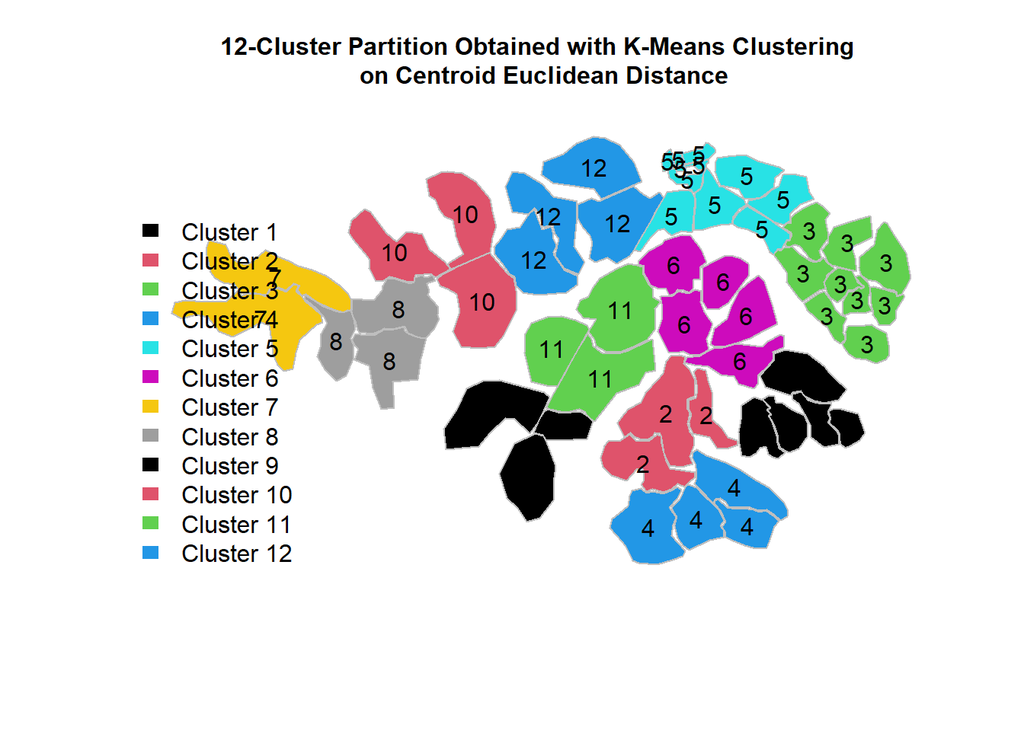

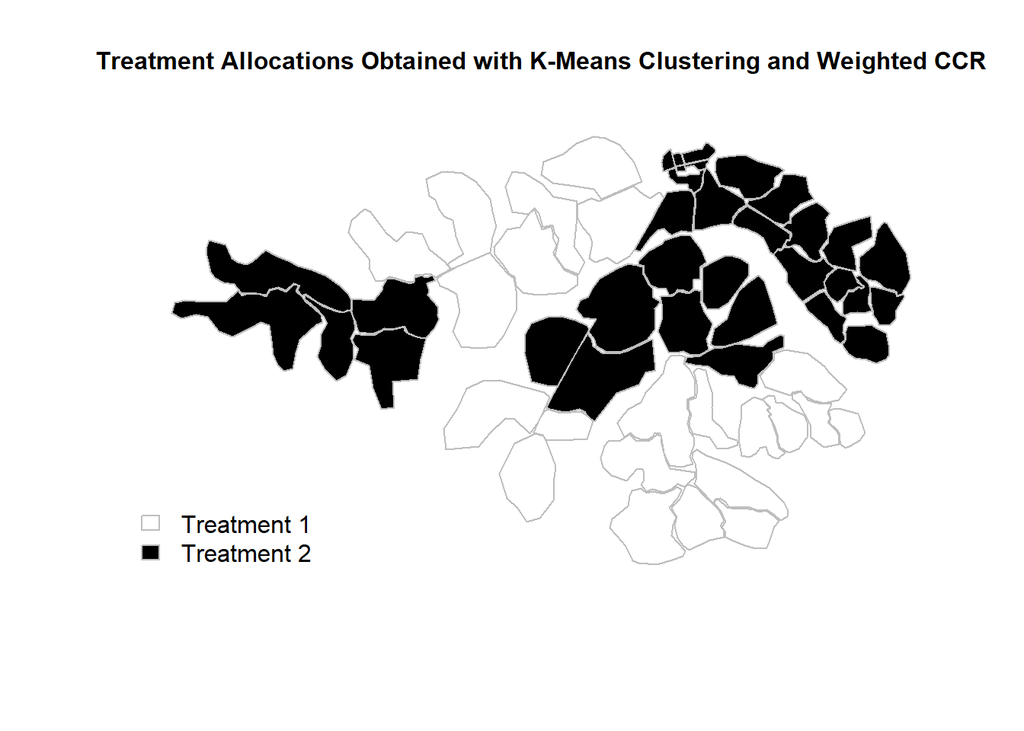

```r
best_scores <-  c(as.numeric(kmeans_best_ccr[[1]]$bscores[1,2]),as.numeric(clara_best_ccr[[1]]$bscores[1,2]),as.numeric(hclust_best_ccr[[1]]$bscores[1,2]))

if (min(best_scores) == best_scores[1]) {
overall_best_design <- kmeans_best_ccr
overall_best_design_df <- kmeans_best_df
best<-"K-Means"
K_best <- K_kmeans
best_clustering <- kmeans_clustering
best_treatments <- kmeans_treatments
  paste("The configuration with the lowest selected CCR score, exhibiting spatial heterogeneity of treatment assignments and balance on strata, is ", best, " with ", K_best, " clusters.",sep = "")

#Summary stats for best selected design
overall_best_design[[1]]$baseline_table

#Visualizing clusters
sp::plot(map,border="grey",col=best_clustering[,1], main= paste(K_best,"-Cluster Partition Obtained with ", best, " Clustering \n on Centroid Euclidean Distance", sep = ""),cex.main=1)
legend("bottomleft", legend=paste("Cluster",1:K_best), fill=1:K_best, bty="n",border="white")
text(coordinates(map), labels = best_clustering[,1])

#Visualizing treatment assignments
sp::plot(map,border="grey",col= best_treatments[,2], main= paste("Treatment Allocations Obtained with ", best," Clustering and Weighted CCR", sep = ""),cex.main=1)
legend("bottomleft", legend=paste("Treatment",1:2), fill=0:1, bty="n",border="grey")

#Saving design
write.csv(overall_best_design[[1]]$baseline_table, "overall_best_ccr_table_Euclidean.csv")
write.csv(overall_best_design_df, "overall_best_ccr_assignments_Euclidean.csv")
} else if (min(best_scores)==best_scores[2]) {
overall_best_design <- clara_best_ccr
overall_best_design_df <- clara_best_df
best <-"CLARA"
K_best <- K_clara
best_clustering <- clara_clustering
best_treatments <- clara_treatments
  paste("The configuration with the lowest selected CCR score, exhibiting spatial heterogeneity of treatment assignments and balance on strata, is ", best, " with ", K_best, " clusters.",sep = "")

#Summary stats for best selected design
overall_best_design$baseline_table

#Visualizing clusters
sp::plot(map,border="grey",col=best_clustering[,1], main= paste(K_best,"-Cluster Partition Obtained with ", best, " Clustering \n on Centroid Euclidean Distance", sep = ""),cex.main=1)
legend("bottomleft", legend=paste("Cluster",1:K_best), fill=1:K_best, bty="n",border="white")
text(coordinates(map), labels = best_clustering[,1])

#Visualizing treatment assignments
sp::plot(map,border="grey",col= best_treatments[,2], main= paste("Treatment Allocations Obtained with ", best," Clustering and Weighted CCR", sep = ""),cex.main=1)
legend("bottomleft", legend=paste("Treatment",1:2), fill=0:1, bty="n",border="grey")

#Saving design
write.csv(overall_best_design[[1]]$baseline_table, "overall_best_ccr_table_Euclidean.csv")
write.csv(overall_best_design_df, "overall_best_ccr_assignments_Euclidean.csv")
} else {
overall_best_design <- hclust_best_ccr
overall_best_design_df <- hclust_best_df
best<-"Ward Hierarchical"
K_best <- K_hclust
best_clustering <- hclust_clustering
best_treatments <- hclust_treatments
  paste("The configuration with the lowest selected CCR score, exhibiting spatial heterogeneity of treatment assignments and balance on strata, is ", best, " with ", K_best, " clusters.",sep = "")

#Saving design
write.csv(overall_best_design[[1]]$baseline_table, "overall_best_ccr_table_Euclidean.csv")
write.csv(overall_best_design_df, "overall_best_ccr_assignments_Euclidean.csv")
}
```

```r
#Saving visualization of clusters
png("best_cluster_assignments_Euclidean.png")
sp::plot(map,border="grey",col=best_clustering[,1], main= paste(K_best,"-Cluster Partition Obtained with ", best, " Clustering \n on Centroid Euclidean Distance", sep = ""),cex.main=1.45)
legend("bottomleft", legend=paste("Cluster",1:K_best), fill=1:K_best, bty="n",border="white")
text(coordinates(map), labels = best_clustering[,1])
dev.off()
```

```r
#Saving visualization of treatment assignments
png(file="best_ccr_assignments_Euclidean.png")
sp::plot(map,border="grey",col= best_treatments[,2], main= paste("Treatment Allocations Obtained with \n ", best," Clustering and Weighted CCR", sep = ""),cex.main=1.45)
legend("bottomleft", legend=paste("Treatment",1:2), fill=0:1, bty="n",border="grey")
dev.off()
```

```r
#Treatment assignments and summary stats
overall_best_design_df
```

```
##    kmeans_cluster village_code Treatment_Group     village_long
## 1               8         01_1               1 33.8830960935419
## 2              12         02_1               0 33.9237745011031
## 3               8         03_1               1 33.8853283079411
## 4              10         04_1               0 33.8842217278614
## 5               7         05_1               1 33.8535994357203
## 6               9         06_1               0 33.9190695733212
## 7               9         07_1               0 33.9094579270079
## 8              10         08_1               0 33.9066931683657
## 9              11         09_1               1  33.942453536588
## 10              9         10_1               0 33.9278261715395
## 11             11         11_1               1 33.9372169816813
## 12              8         12_1               1 33.8692483873845
## 13             12         13_1               0 33.9201148561385
## 14             10         14_1               0 33.9023331821086
```

[output cut: 97 more lines]

```r
#Optimal selected configuration treatment table
overall_best_design[[1]]$baseline_table
```

```
##                                             arm = 0       arm = 1
## n                                                 6             6
## Cluster_mRate_1 (mean (SD))             0.24 (0.06)   0.24 (0.03)
## Cluster_hhDensity (mean (SD))          51.90 (9.52) 54.43 (15.85)
## Cluster_prop_BordersWater (mean (SD))   0.51 (0.42)   0.58 (0.35)
## county = 3 (%)                            3 (50.0)      3 (50.0)
```

```r
#CCR scores
overall_best_design[[1]]$bscores
```

```
##
## 1  score (selected scheme)      429.534
## 2             cutoff score     2941.384
## 3                     Mean  3011374.428
## 4                       SD  4087601.446
## 5                      Min      111.955
## 6                       5%     1578.637
## 7                      10%     3060.958
## 8                      20%     6670.574
## 9                      25%     8524.586
## 10                     30%    10588.121
## 11                     50%  3669107.691
## 12                     75%  3678553.360
## 13                     95% 14678305.852
## 14                     Max 33032641.563
```

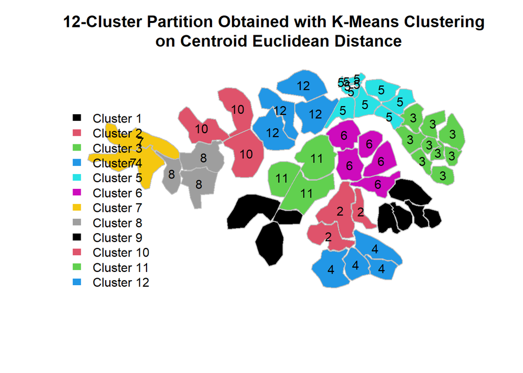

```r
#Visualization of clusters
sp::plot(map,border="grey",col=best_clustering[,1], main= paste(K_best,"-Cluster Partition Obtained with ", best, " Clustering \n on Centroid Euclidean Distance", sep = ""),cex.main=1.3)
legend("bottomleft", legend=paste("Cluster",1:K_best), fill=1:K_best, bty="n",border="white")
text(coordinates(map), labels = best_clustering[,1])
```

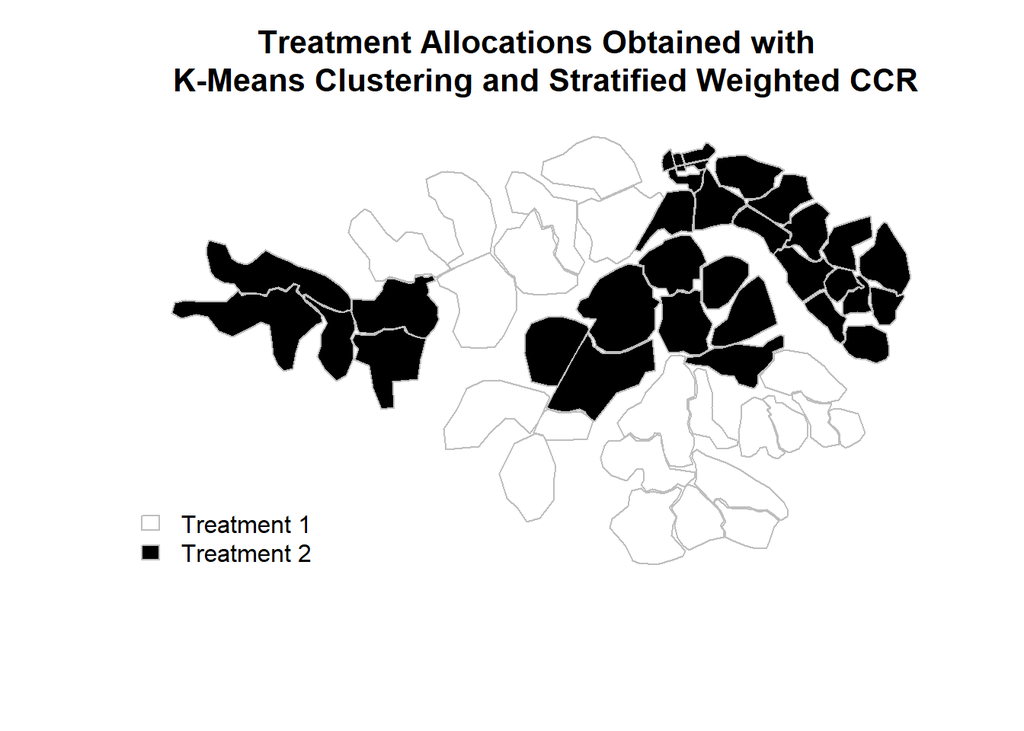

```r
#Visualization of treatment assignments
sp::plot(map,border="grey",col= best_treatments[,2], main= paste("Treatment Allocations Obtained with \n ", best," Clustering and Stratified Weighted CCR", sep = ""),cex.main=1.3)
legend("bottomleft", legend=paste("Treatment",1:2), fill=0:1, bty="n",border="grey")
```

References

[1] Moulton LH. Covariate-based constrained randomization of group-randomized trials. Clinical Trials 2004;1(3):297–305.

[2] Dickinson LM, Beaty B, Fox C, Pace W, Dickinson WP, Emsermann C, et al. Pragmatic Cluster Randomized Trials Using Covariate Constrained Randomization: A Method for Practice-based Research Networks (PBRNs). The Journal of the American Board of Family Medicine 2015;28(5):663–672.

[3] Keogh-Brown M, Bachmann M, Shepstone L, Hewitt C, Howe A, Ramsay C, et al. Contamination in trials of educational interventions. Health technology assessment (Winchester, England) 2007 11;11:iii, ix–107.

[4] Manning CD, Raghavan P, Schütze H. Introduction to Information Retrieval. Cambridge University Press; 2018.

[5] Kaufman L, Rousseeuw P. Finding Groups in Data: An Introduction To Cluster Analysis; 1990.

[6] Bishop CM. Neural Networks for Pattern Recognition. New York, NY, USA: Oxford University Press, Inc.; 1995.

[7] Distance;. http://mathworld.wolfram.com/Distance.html.

[8] Jin X, Han J. In: Sammut C, Webb GI, editors. K-Medoids Clustering Boston, MA: Springer US; 2010. p. 564–565.

[9] R Core Team. R: A Language and Environment for Statistical Computing. R Foundation for Statistical Computing, Vienna, Austria; 2018, https://www.R-project.org/.

[10] Raab GM, Butcher I. Balance in cluster randomized trials. Statistics in Medicine 2001;20(3):351–365.

[11] Yu H, Li F, Gallis JA, Turner EL. cvcrand: Efficient Design and Analysis of Cluster Randomized Trials; 2019, https://CRAN.R-project.org/package=cvcrand, r package version 0.0.3.

[12] Elizabeth A Albright P, Two Independent Samples Unequal Variance (Welch’s Test). Duke; 2018. https://sites.nicholas.duke.edu/statsreview/means/welch/.

[13] Ram A, Jalal S, Jalal AS, Kumar M. A Density Based Algorithm for Discovering Density Varied Clusters in Large Spatial Databases. International Journal of Computer Applications 2010;3(6):1–4.

[14] Kamil I, Almamory S. Data Partitioning Technique to Enhance DBSCAN Clustering Algorithm 2018 03;Vol.(25).

[15] Hahsler M, Piekenbrock M, Doran D. dbscan: Fast Density-Based Clustering with R. Journal of Statistical Software 2019;91(1):1–30.

[16] Pebesma EJ, Bivand RS. Classes and methods for spatial data in R. R News 2005 November;5(2):9–13. https://CRAN.Rproject.org/doc/Rnews/.

[17] Bivand RS, Pebesma E, Gomez-Rubio V. Applied spatial data analysis with R, Second edition. Springer, NY; 2013. http://www.asdar-book.org/.

[18] Maechler M, Rousseeuw P, Struyf A, Hubert M, Hornik K. cluster: Cluster Analysis Basics and Extensions; 2018, r package version 2.0.7-1.

[19] Hartigan JA, Wong MA. Algorithm AS 136: A K-Means Clustering Algorithm. Journal of the Royal Statistical Society Series C (Applied Statistics) 1979;28(1):100–108.

[20] Baddeley A, Turner R. spatstat: An R Package for Analyzing Spatial Point Patterns. Journal of Statistical Software 2005;12(6):1–42.